# DS_Challenge

## CapitalOne Data Challenge

#### Import Raw Data

```python
# import package
import pandas as pd
import seaborn as sns
import numpy as np
import matplotlib.pyplot as plt
import matplotlib.style as style
import matplotlib.colors as mcolors
import plotly.express as px
import warnings
warnings.filterwarnings("ignore")
from sklearn.model_selection import train_test_split
from sklearn.ensemble import GradientBoostingClassifier
from sklearn.metrics import accuracy_score, precision_score, recall_score, f1_score, confusion_matrix, roc_curve
from sklearn.impute import SimpleImputer
from sklearn.preprocessing import OneHotEncoder
from sklearn.pipeline import Pipeline
from sklearn.compose import ColumnTransformer
from imblearn.under_sampling import RandomUnderSampler
from sklearn.preprocessing import FunctionTransformer
from sklearn.ensemble import RandomForestClassifier
from sklearn.model_selection import RandomizedSearchCV
import xgboost as xgb
from xgboost import XGBClassifier
from sklearn.model_selection import GridSearchCV
```

```python
# directory of the file
path= './transactions.txt'
```

```python
# data import function
def import_data(path):
    l = []
    df = pd.DataFrame()
    for iot_chunk in pd.read_json(path, lines = True, chunksize = 1000) :
        l.append(iot_chunk)
    df = pd.concat(l, sort = False)
    return df
```

```python
# pandas setting
pd.set_option('display.max_columns', None)
trans = import_data(path)
trans.head()
```

|  | accountNumber | customerId | creditLimit | availableMoney | transactionDateTime | transactionAmount | merchantName | acqCountry | merchantCountryCode | posEntryMode | posConditionCode | merchantCategoryCode | currentExpDate | accountOpenDate | dateOfLastAddressChange | cardCVV | enteredCVV | cardLast4Digits | transactionType | echoBuffer | currentBalance | merchantCity | merchantState | merchantZip | cardPresent | posOnPremises | recurringAuthInd | expirationDateKeyInMatch | isFraud |
| --- | --- | --- | --- | --- | --- | --- | --- | --- | --- | --- | --- | --- | --- | --- | --- | --- | --- | --- | --- | --- | --- | --- | --- | --- | --- | --- | --- | --- | --- |
| 0 | 737265056 | 737265056 | 5000 | 5000.0 | 2016-08-13T14:27:32 | 98.55 | Uber | US | US | 02 | 1 | rideshare | 06/2023 | 2015-03-14 | 2015-03-14 | 414 | 414 | 1803 | PURCHASE |  | 0.0 |  |  |  | False |  |  | False | False |
| 1 | 737265056 | 737265056 | 5000 | 5000.0 | 2016-10-11T05:05:54 | 74.51 | AMC #191138 | US | US | 09 | 1 | entertainment | 02/2024 | 2015-03-14 | 2015-03-14 | 486 | 486 | 767 | PURCHASE |  | 0.0 |  |  |  | True |  |  | False | False |
| 2 | 737265056 | 737265056 | 5000 | 5000.0 | 2016-11-08T09:18:39 | 7.47 | Play Store | US | US | 09 | 1 | mobileapps | 08/2025 | 2015-03-14 | 2015-03-14 | 486 | 486 | 767 | PURCHASE |  | 0.0 |  |  |  | False |  |  | False | False |
| 3 | 737265056 | 737265056 | 5000 | 5000.0 | 2016-12-10T02:14:50 | 7.47 | Play Store | US | US | 09 | 1 | mobileapps | 08/2025 | 2015-03-14 | 2015-03-14 | 486 | 486 | 767 | PURCHASE |  | 0.0 |  |  |  | False |  |  | False | False |
| 4 | 830329091 | 830329091 | 5000 | 5000.0 | 2016-03-24T21:04:46 | 71.18 | Tim Hortons #947751 | US | US | 02 | 1 | fastfood | 10/2029 | 2015-08-06 | 2015-08-06 | 885 | 885 | 3143 | PURCHASE |  | 0.0 |  |  |  | True |  |  | False | False |

```python
# size of the dataset
print("Dataset Dimensions: {} x {}".format(trans.shape[0], trans.shape[1]))
```

```
Dataset Dimensions: 786363 x 29
```

```python
# column names of all the features
np.array(trans.columns)
```

```
array(['accountNumber', 'customerId', 'creditLimit', 'availableMoney',
       'transactionDateTime', 'transactionAmount', 'merchantName',
       'acqCountry', 'merchantCountryCode', 'posEntryMode',
       'posConditionCode', 'merchantCategoryCode', 'currentExpDate',
       'accountOpenDate', 'dateOfLastAddressChange', 'cardCVV',
       'enteredCVV', 'cardLast4Digits', 'transactionType', 'echoBuffer',
       'currentBalance', 'merchantCity', 'merchantState', 'merchantZip',
       'cardPresent', 'posOnPremises', 'recurringAuthInd',
       'expirationDateKeyInMatch', 'isFraud'], dtype=object)
```

```python
# replace "" with None as Python does not count empty/null values as NaN
trans = trans.replace(r'', None, regex = True)
```

```python
# count null values for each column
trans.isnull().sum()
```

```
accountNumber                    0
customerId                       0
creditLimit                      0
availableMoney                   0
transactionDateTime              0
transactionAmount                0
merchantName                     0
acqCountry                    4562
merchantCountryCode            724
posEntryMode                  4054
posConditionCode               409
merchantCategoryCode             0
currentExpDate                   0
accountOpenDate                  0
dateOfLastAddressChange          0
cardCVV                          0
enteredCVV                       0
cardLast4Digits                  0
transactionType                698
echoBuffer                  786363
currentBalance                   0
merchantCity                786363
merchantState               786363
merchantZip                 786363
cardPresent                      0
posOnPremises               786363
recurringAuthInd            786363
expirationDateKeyInMatch         0
isFraud                          0
dtype: int64
```

```python
# remove the empty columns
na_sum = trans.isnull().sum()
remove_idx = na_sum[na_sum == 786363].index
remove_list = np.array(remove_idx)
trans.drop(remove_list, axis = 1, inplace = True)
```

```python
# preliminary statistics of the numeric features
trans.describe()
```

|  | accountNumber | customerId | creditLimit | availableMoney | transactionAmount | cardCVV | enteredCVV | cardLast4Digits | currentBalance |
| --- | --- | --- | --- | --- | --- | --- | --- | --- | --- |
| count | 7.863630e+05 | 7.863630e+05 | 786363.000000 | 786363.000000 | 786363.000000 | 786363.000000 | 786363.000000 | 786363.000000 | 786363.000000 |
| mean | 5.372326e+08 | 5.372326e+08 | 10759.464459 | 6250.725369 | 136.985791 | 544.467338 | 544.183857 | 4757.417799 | 4508.739089 |
| std | 2.554211e+08 | 2.554211e+08 | 11636.174890 | 8880.783989 | 147.725569 | 261.524220 | 261.551254 | 2996.583810 | 6457.442068 |
| min | 1.000881e+08 | 1.000881e+08 | 250.000000 | -1005.630000 | 0.000000 | 100.000000 | 0.000000 | 0.000000 | 0.000000 |
| 25% | 3.301333e+08 | 3.301333e+08 | 5000.000000 | 1077.420000 | 33.650000 | 310.000000 | 310.000000 | 2178.000000 | 689.910000 |
| 50% | 5.074561e+08 | 5.074561e+08 | 7500.000000 | 3184.860000 | 87.900000 | 535.000000 | 535.000000 | 4733.000000 | 2451.760000 |
| 75% | 7.676200e+08 | 7.676200e+08 | 15000.000000 | 7500.000000 | 191.480000 | 785.000000 | 785.000000 | 7338.000000 | 5291.095000 |
| max | 9.993896e+08 | 9.993896e+08 | 50000.000000 | 50000.000000 | 2011.540000 | 998.000000 | 998.000000 | 9998.000000 | 47498.810000 |

```python
# transactions with physical card vs. transaction online without card present
round(sum(trans.cardPresent)/len(trans), 4)
```

```
0.4487
```

```python
# unique customer account
trans.accountNumber.nunique()
```

```
5000
```

```python
# accountNumber = customerId
comp = trans.accountNumber == trans.customerId
comp.all()
```

```
True
```

#### Given 29 available dataset features, it is better to remove echoBuffer, merchantCity, merchantState, merchantZip, posOnPremises and recurringAuthInd, as these are empty. There are total of 786363 records with features among Timestamp: 4 columns, Boolean : 3 columns, Categorical: 7 columns, Numerical: 9 columns.

#### Both accountNumber and customerId are exactly the same. And there are 5000 unique customers in the dataset.

#### Keep cardCVV and enteredCVV to see the difference if any.

#### Exploratory Data Analysis -- Plot

```python
plt.style.available
sns.set_style('ticks')
```

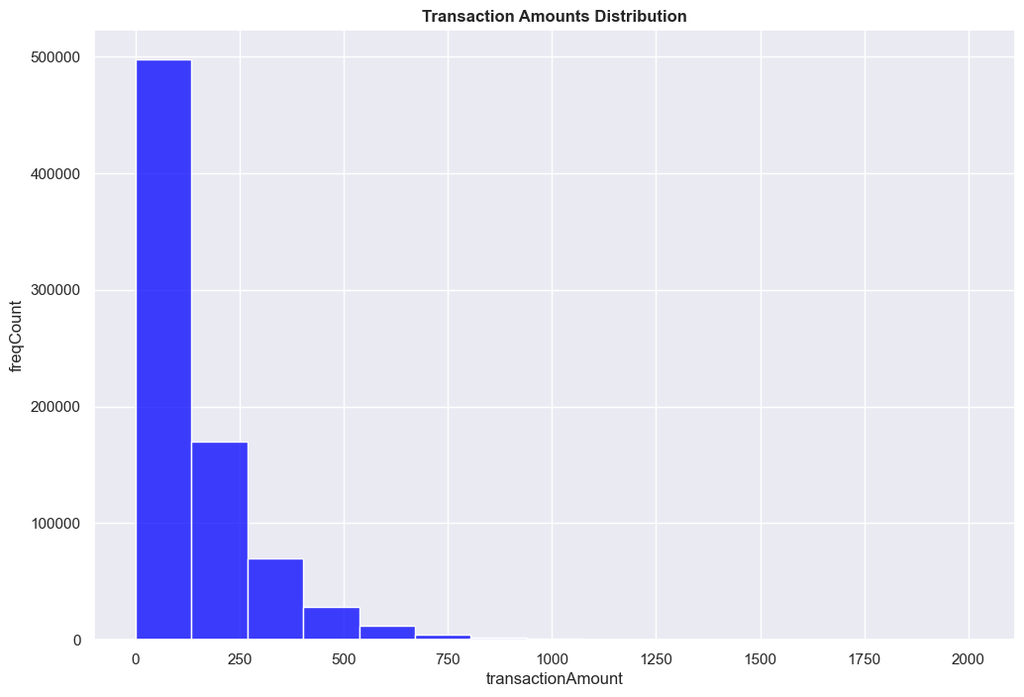

```python
# visualize transaction amounts by using the histogram
plt.figure(figsize = (12, 8))
sns.set_theme()

ax=sns.histplot(data = trans, x = "transactionAmount", color = 'blue', bins = 15)
ax.set(xlabel='transactionAmount')
ax.set(ylabel='freqCount')
plt.title('Transaction Amounts Distribution', weight='bold')
```

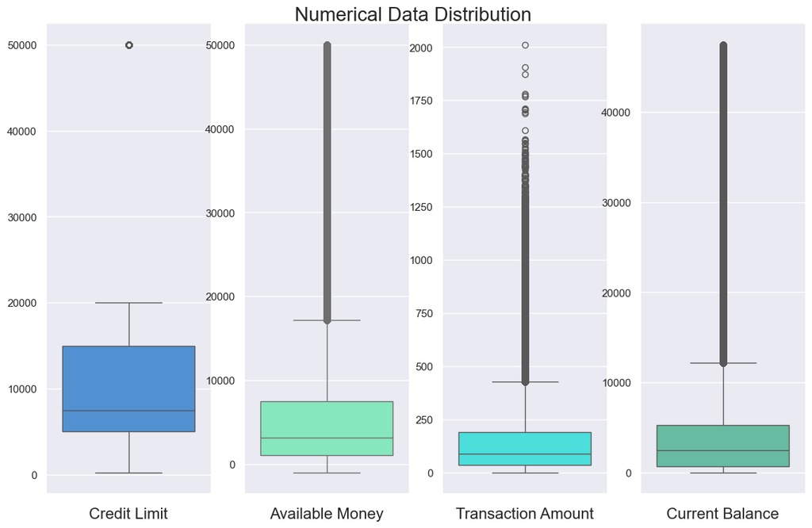

```python
fig, ax = plt.subplots(nrows = 1, ncols = 4, figsize = (14, 8))

numeric_cols = ['creditLimit', 'availableMoney', 'transactionAmount', 'currentBalance']
neat_cols = ['Credit Limit', 'Available Money', 'Transaction Amount', 'Current Balance']
colors = ['#3C91E6', '#76F7BF', '#34F6F2', '#59C9A5']

for i in range(len(numeric_cols)):
    # set boxplot vertical with y
    sns.boxplot(data = trans, y = numeric_cols[i], ax = ax[i], color = colors[i], orient = 'v')
    ax[i].set_xlabel(neat_cols[i], fontsize = 16)
    ax[i].set_ylabel('')
plt.suptitle('Numerical Data Distribution', fontsize = 20)
fig.subplots_adjust(top = 0.95)
```

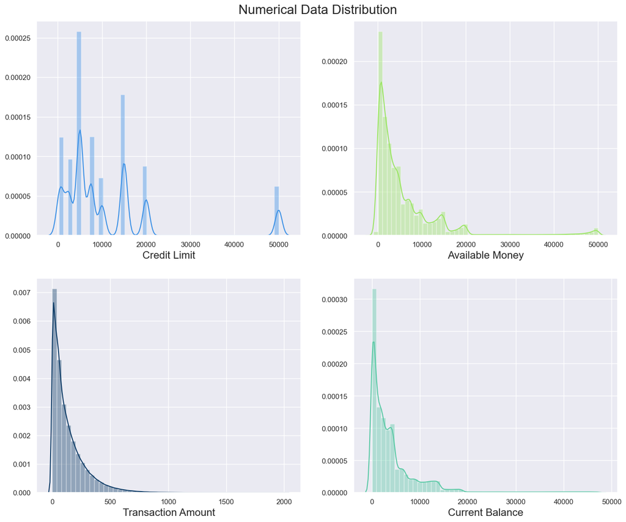

```python
fig, ax = plt.subplots(nrows = 2, ncols = 2, figsize = (16, 12))

numeric_cols = ['creditLimit', 'availableMoney', 'transactionAmount', 'currentBalance']
neat_cols = ['Credit Limit', 'Available Money', 'Transaction Amount', 'Current Balance']
colors = ['#3C91E6', '#9BE564', '#0D3B66', '#59C9A5']
counter = 0

for i in range(2):
    for j in range(2):
        sns.distplot(trans[numeric_cols[counter]], ax = ax[i][j], color = colors[counter])
        ax[i][j].set_xlabel(neat_cols[counter], fontsize = 16)
        ax[i][j].set_ylabel('')
        counter += 1
plt.suptitle('Numerical Data Distribution', fontsize = 20)
fig.subplots_adjust(top = 0.95)
```

#### Credit Limit:

##### 1. Some really far outliers at credit limit of 50,000 but expected since a higher credit limit is not easily achieved

##### 2. Also it does not seem to have a normal distribution

#### Available Money

##### 1. It looks very right skewed

##### 2. It is interesting to see that available money is so low and more outliers as money increases

#### Transaction Amount

##### 1. It is right skewed

##### 2. It seems that the general transaction amount is typically low, but it is understandable as usually people dont spend hundreds of dollars everyday

##### 3. The maximum transaction amount in this data set is ~2000

#### Current Balance

##### 1. It is right skewed

##### 2. Again, the balance for the bank customers looks quite low.

```python
# more than half of transactions are less than $125 in the dataset
round(len(trans[(trans.transactionAmount < 125)])/len(trans), 4)
```

```
0.61
```

```python
# card limit category
trans.creditLimit.unique()
```

```
array([ 5000,  2500, 50000, 15000, 10000,   250,   500,  1000,  7500,
       20000])
```

```
[Text(0.5, 1.0, 'Transaction Amount vs Credit Limit')]
```

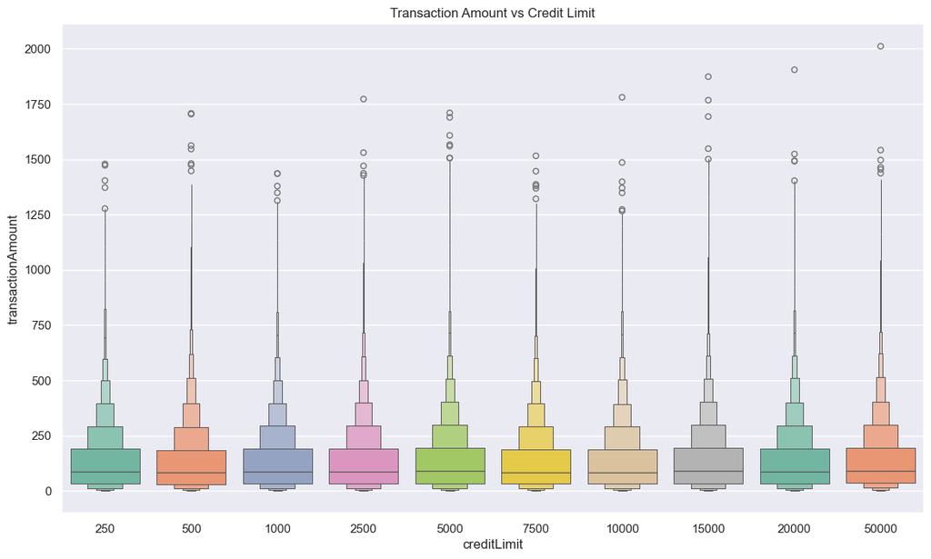

```python
l = ['creditLimit', 'transactionAmount']
plt.figure(figsize = (14, 8))
sns.set_theme()
sns.boxenplot(x = l[0], y = l[1], palette = 'Set2', data = trans.sort_values(l[0])).set(title = 'Transaction Amount vs Credit Limit')
```

#### Intuitive assumption is that having a higher credit limit would lead to more expensive and more overall transactions, but it turns out very different. Maybe people with high credit limits are wiser with money management and do not spend it recklessly.

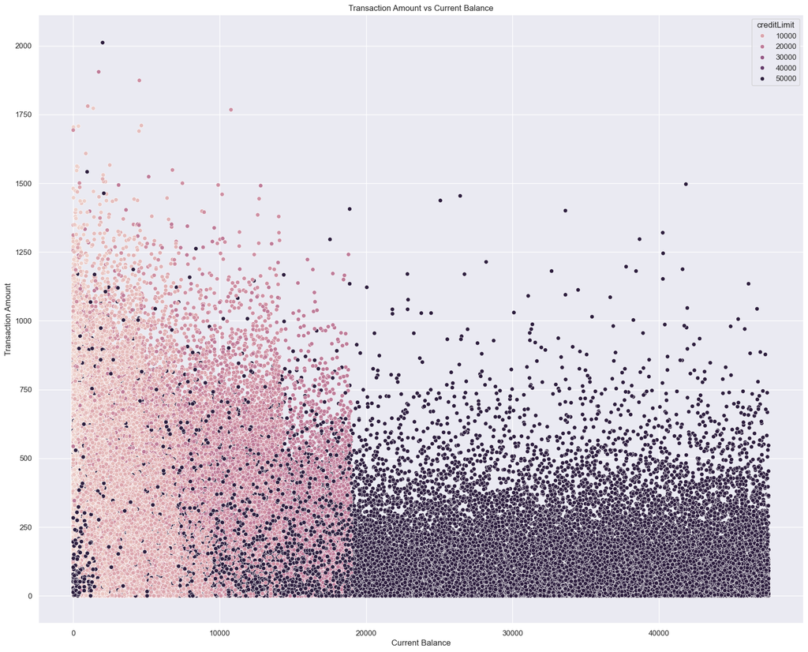

```python
plt.figure(figsize = (20, 16))
sns.set_theme()
sns.scatterplot(data = trans, x = 'currentBalance', y = 'transactionAmount', hue = 'creditLimit')
plt.xlabel('Current Balance')
plt.ylabel('Transaction Amount')
plt.title('Transaction Amount vs Current Balance')
```

#### Customers with larger balances tend to have higher credit limits

#### Interesting finding is that some people with really high credit limits have 0 in their current balance

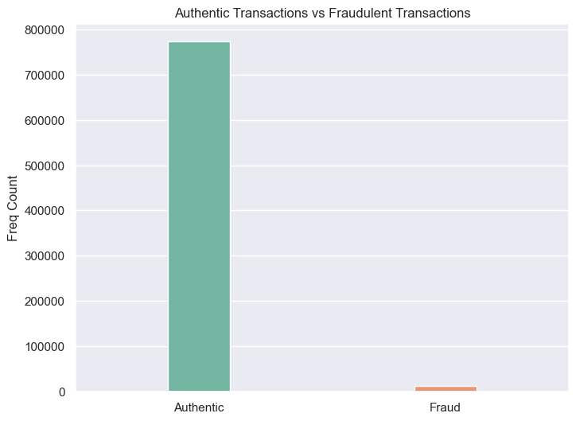

```python
fraud_ct = trans['isFraud'].value_counts()
plt.figure(figsize = (8, 6))
sns.set_theme()
sns.barplot(x = [0, 1], y = fraud_ct, palette = 'Set2', width = 0.25).set(title = 'Authentic Transactions vs Fraudulent Transactions')
plt.xticks(ticks = [0, 1], labels = ['Authentic', 'Fraud'])
plt.ylabel('Freq Count')
```

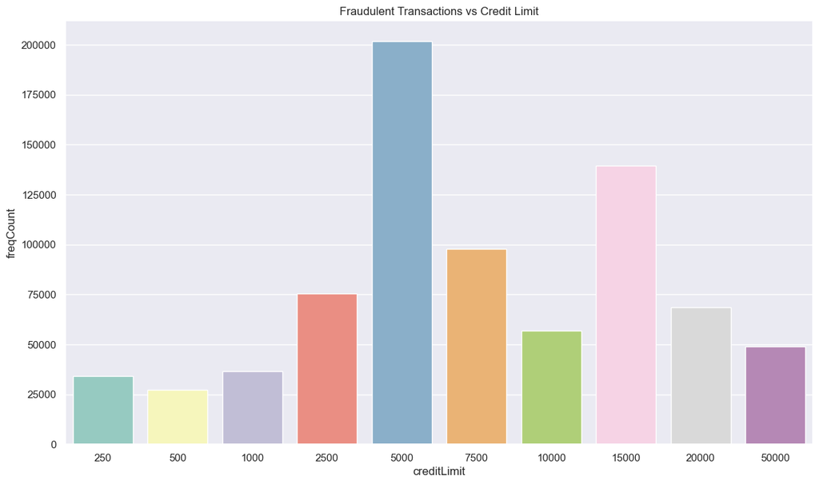

```python
# draw histogram
g = pd.DataFrame(trans.groupby('creditLimit').count()['isFraud']).reset_index(drop = False)
g.columns = ['creditLimit', 'freqCount']
plt.figure(figsize = (14, 8))
sns.set_theme()
ax = sns.barplot(x = g.columns[0], y = g.columns[1], palette = 'Set3', data = g).set(title = 'Fraudulent Transactions vs Credit Limit')
```

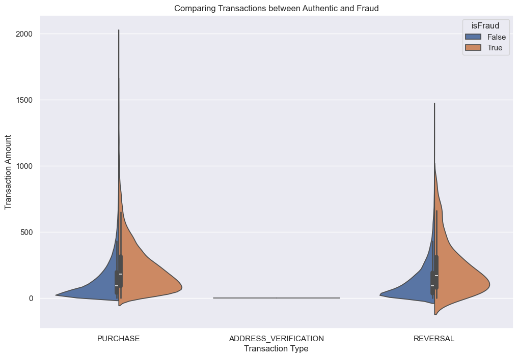

```python
plt.figure(figsize = (12, 8))
sns.set_theme()
sns.violinplot(x = 'transactionType', y = 'transactionAmount', data = trans, hue = 'isFraud', split = True)
plt.xlabel('Transaction Type')
plt.ylabel('Transaction Amount')
plt.title('Comparing Transactions between Authentic and Fraud')
```

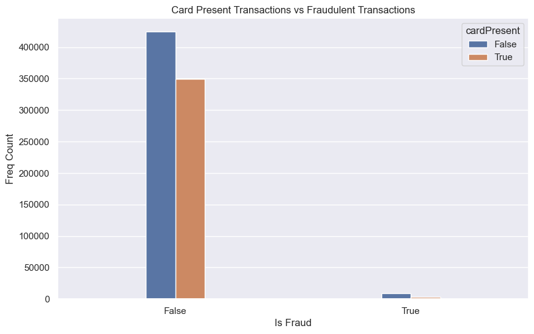

```python
plt.figure(figsize = (10, 6))
sns.set_theme()
sns.countplot(data = trans, x = 'isFraud', hue = 'cardPresent', width = 0.25)
plt.xlabel('Is Fraud')
plt.ylabel('Freq Count')
plt.title('Card Present Transactions vs Fraudulent Transactions')
```

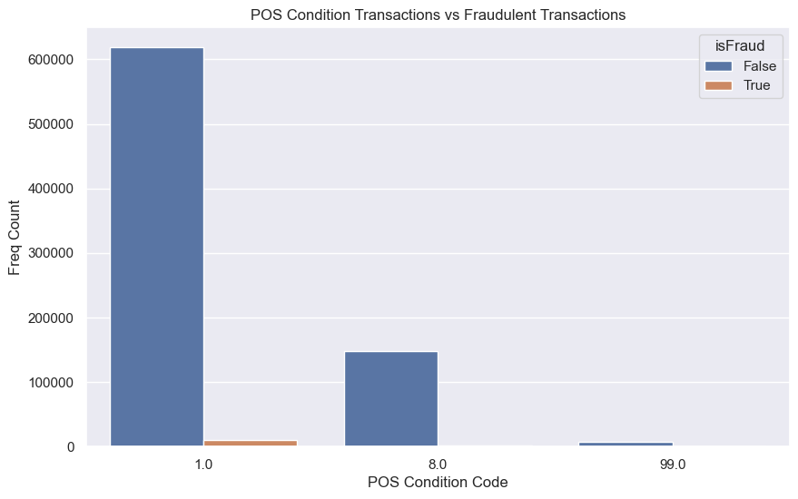

```python
plt.figure(figsize = (10, 6))
sns.set_theme()
sns.countplot(data = trans, x = 'posConditionCode', hue = 'isFraud')
plt.xlabel('POS Condition Code')
plt.ylabel('Freq Count')
plt.title('POS Condition Transactions vs Fraudulent Transactions')
```

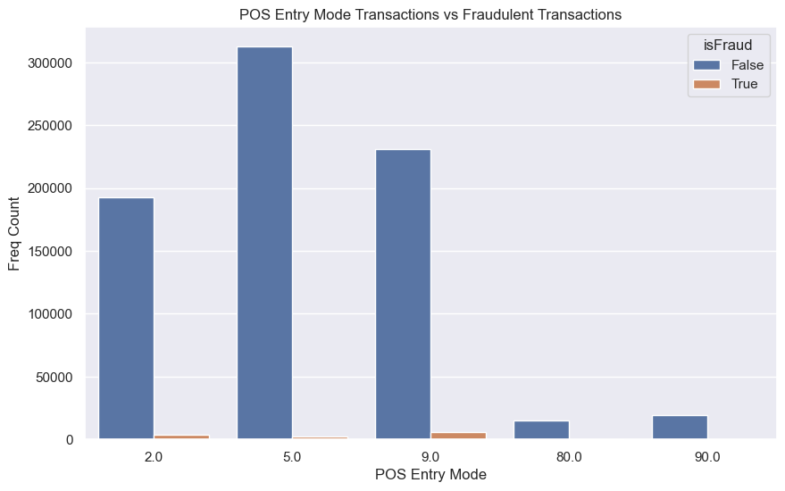

```python
plt.figure(figsize = (10, 6))
sns.set_theme()
sns.countplot(data = trans, x = 'posEntryMode', hue = 'isFraud')
plt.xlabel('POS Entry Mode')
plt.ylabel('Freq Count')
plt.title('POS Entry Mode Transactions vs Fraudulent Transactions')
```

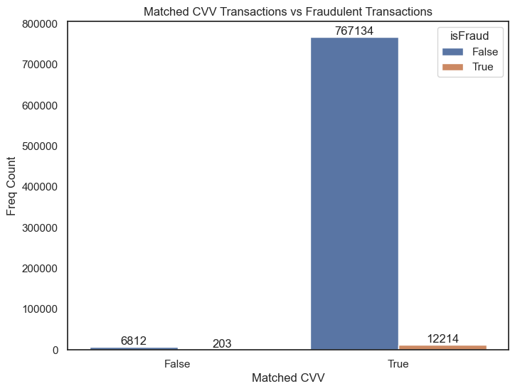

```python
trans['matchedCVV'] = trans['cardCVV'] == trans['enteredCVV']
plt.figure(figsize = (8, 6))
sns.set_theme(style = 'white')
ax = sns.countplot(data = trans, x = 'matchedCVV', hue = 'isFraud')
for label in ax.containers:
    ax.bar_label(label)
plt.xlabel('Matched CVV')
plt.ylabel('Freq Count')
plt.title('Matched CVV Transactions vs Fraudulent Transactions')
```

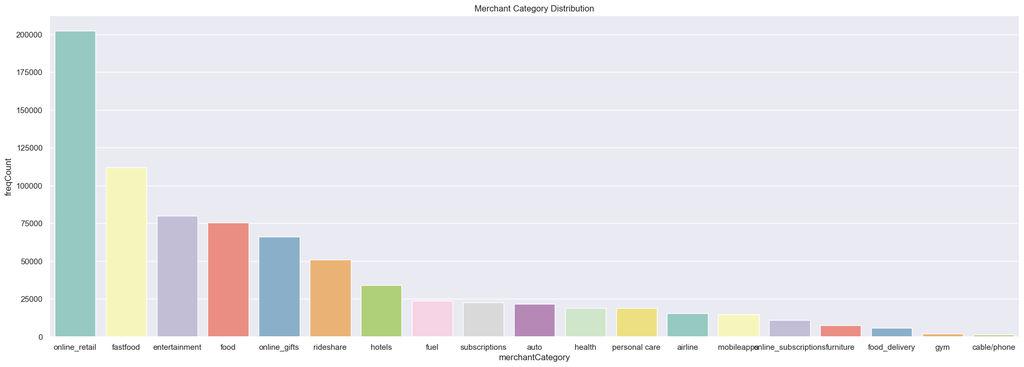

```python
# draw histogram
c = pd.DataFrame(trans['merchantCategoryCode'].value_counts()).reset_index(drop = False)
c.columns = ['merchantCategory', 'freqCount'] # rename columns
plt.figure(figsize = (24,8)) # adjust figure size
sns.set_theme() # set theme
ax = sns.barplot(x = c.columns[0], y = c.columns[1], palette = 'Set3', data = c).set(title = 'Merchant Category Distribution')
```

```python
trans.acqCountry.unique()
```

```
array(['US', nan, 'CAN', 'MEX', 'PR'], dtype=object)
```

```python
trans.merchantCountryCode.unique()
```

```
array(['US', 'CAN', nan, 'PR', 'MEX'], dtype=object)
```

```
  acqCountry  freqCount
0         US     774709
1        MEX       3130
2        CAN       2424
3         PR       1538
```

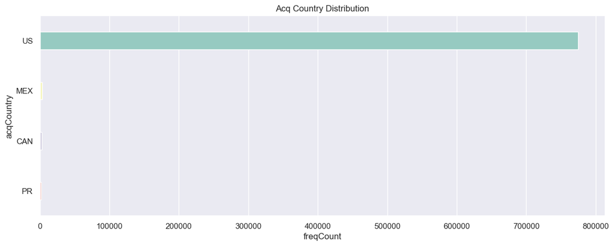

```python
# draw histogram
l = pd.DataFrame(trans.acqCountry.value_counts()).reset_index(drop = False)
l.columns = ['acqCountry','freqCount']
print(l)
plt.figure(figsize = (14, 5))
sns.set_theme()
ax = sns.barplot(x = l.columns[1], y = l.columns[0], palette = 'Set3', data = l, width = 0.35).set(title = 'Acq Country Distribution')
```

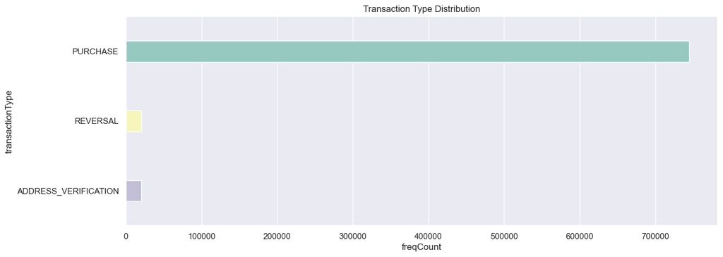

```python
# draw histogram
t = pd.DataFrame(trans.transactionType.value_counts()).reset_index(drop = False)
t.columns = ['transactionType','freqCount']
plt.figure(figsize = (14, 5))
sns.set_theme()
ax = sns.barplot(x = t.columns[1], y = t.columns[0], palette = 'Set3', data = t, width = 0.3).set(title = 'Transaction Type Distribution')
```

```python
# print minimum and maximum transaction dates of the dataset
print(trans.transactionDateTime.min(), trans.transactionDateTime.max())
```

```
2016-01-01T00:01:02 2016-12-30T23:59:45
```

```python
trans['date'] = trans['transactionDateTime'].apply(lambda x: x.split('T')[0])
cust_merch = trans.groupby(['customerId', 'merchantName']).count()['date']
cust_merch = pd.DataFrame(cust_merch).reset_index()
cust_merch.columns = ['customerId','merchantName', 'freqCount']
cust_merch = cust_merch.sort_values(by = 'freqCount', ascending = False)
cust_merch.head()
```

|  | customerId | merchantName | freqCount |
| --- | --- | --- | --- |
| 70283 | 380680241 | Next Day eCards | 4094 |
| 70168 | 380680241 | Fresh eCards | 4065 |
| 70167 | 380680241 | Fresh Online Services | 4042 |
| 70102 | 380680241 | Blue Mountain eCards | 4037 |
| 70166 | 380680241 | Fresh Flowers | 4024 |

#### Data Wrangling -- Duplicate Transactions

```python
trans.reset_index(drop = False, inplace = True)
trans['transactionKey'] = trans['index'].apply(lambda x: str('T') + str(x))
trans.drop(['index'], axis = 1, inplace = True)
trans.head()
```

```python
df = trans.copy()
df['time'] = df['transactionDateTime'].apply(lambda x: x.split('T')[1])
df['transactionType'] = df.transactionType.fillna(value = 'PURCHASE')
df.date = pd.to_datetime(df.date)
df['timeStamp'] = pd.to_datetime(df.date.astype(str) + ' ' + df.time.astype(str))
```

```python
data = df[['customerId', 'merchantName', 'transactionAmount', 'transactionType', 'transactionKey', 'timeStamp']]
# sort data in order to detect reversal transaction
data = data.sort_values(by=['customerId', 'merchantName', 'timeStamp'], ascending = True)
# transaction types
print(data.transactionType.unique())
data[data.transactionType == 'ADDRESS_VERIFICATION'].describe()
```

```
['PURCHASE' 'REVERSAL' 'ADDRESS_VERIFICATION']
```

|  | customerId | transactionAmount | timeStamp |
| --- | --- | --- | --- |
| count | 2.016900e+04 | 20169.0 | 20169 |
| mean | 5.329038e+08 | 0.0 | 2016-07-02 04:09:17.046110464 |
| min | 1.003280e+08 | 0.0 | 2016-01-01 00:02:19 |
| 25% | 3.255871e+08 | 0.0 | 2016-04-03 09:03:37 |
| 50% | 4.962259e+08 | 0.0 | 2016-07-01 19:37:23 |
| 75% | 7.634138e+08 | 0.0 | 2016-10-01 06:55:18 |
| max | 9.992836e+08 | 0.0 | 2016-12-30 23:39:18 |
| std | 2.545921e+08 | 0.0 | NaN |

```python
# keep transactionType other than 'ADDRESS_VERIFICATION'
av_re = data[data.transactionType != 'ADDRESS_VERIFICATION']
av_re = av_re.reset_index(drop = True)
av_re.describe()
```

|  | customerId | transactionAmount | timeStamp |
| --- | --- | --- | --- |
| count | 7.661940e+05 | 766194.000000 | 766194 |
| mean | 5.373466e+08 | 140.591753 | 2016-07-06 04:27:10.023701760 |
| min | 1.000881e+08 | 0.000000 | 2016-01-01 00:01:02 |
| 25% | 3.301333e+08 | 37.030000 | 2016-04-06 21:39:42.500000 |
| 50% | 5.074561e+08 | 91.820000 | 2016-07-08 08:56:28.500000 |
| 75% | 7.676200e+08 | 195.400000 | 2016-10-05 16:17:58.750000128 |
| max | 9.993896e+08 | 2011.540000 | 2016-12-30 23:59:45 |
| std | 2.554421e+08 | 147.953816 | NaN |

```python
# reversal transaction
reverse_idx = av_re[av_re.transactionType == 'REVERSAL'].index.values
```

```python
check = pd.DataFrame(reverse_idx - 1)
check.columns=['purchaseIndex']
check['reversalIndex'] = pd.DataFrame(reverse_idx)
check['purchaseAmount'] = pd.DataFrame(av_re.iloc[reverse_idx - 1]['transactionAmount'].values)
check['reversalAmount'] = pd.DataFrame(av_re.iloc[reverse_idx]['transactionAmount'].values)
```

```python
check['flag'] = check[['purchaseAmount', 'reversalAmount']].apply(lambda x: True if (x[0] != x[1]) else False, axis = 1)
checked = check[check.reversalAmount > 0]
checked.flag.value_counts()
```

```
flag
False    12665
True      7066
Name: count, dtype: int64
```

```python
match = av_re.iloc[checked[checked.flag == False].reversalIndex.values]
purchase = av_re[~(av_re.transactionType == 'REVERSAL')] # av_re[-(av_re.transactionType == 'REVERSAL')]
matched = match.merge(purchase.drop_duplicates(subset = ['customerId', 'merchantName', 'transactionAmount'], keep = 'first'),
                      on = ['customerId', 'merchantName', 'transactionAmount'], how = 'left')
matched['priorPurchase'] = matched.timeStamp_x > matched.timeStamp_y
matched['priorPurchase'].value_counts()
```

```
priorPurchase
True    12665
Name: count, dtype: int64
```

```python
mismatch = av_re.iloc[checked[checked.flag == True].reversalIndex.values]
purchase = av_re[av_re.transactionType == 'PURCHASE']
paired = mismatch.merge(purchase.drop_duplicates(subset = ['customerId', 'merchantName', 'transactionAmount'], keep = 'first'),
                        on = ['customerId', 'merchantName', 'transactionAmount'], how = 'left')
paired['priorPurchase'] = paired.timeStamp_x > paired.timeStamp_y
paired['priorPurchase'].value_counts()
```

```
priorPurchase
True     5110
False    1956
Name: count, dtype: int64
```

```python
print("There are {} ".format(len(paired.priorPurchase)) +
      "reversal transactions not following a previous purchase but {} ".format(paired.priorPurchase.value_counts()[0]) +
      "of these can be paired with a prior purchase")
```

```
There are 7066 reversal transactions not following a previous purchase but 5110 of these can be paired with a prior purchase
```

```python
paired[(paired.priorPurchase == False) & (paired.transactionType_y != 'PURCHASE')]
```

|  | customerId | merchantName | transactionAmount | transactionType_x | transactionKey_x | timeStamp_x | transactionType_y | transactionKey_y | timeStamp_y | priorPurchase |
| --- | --- | --- | --- | --- | --- | --- | --- | --- | --- | --- |
| 0 | 101380713 | sears.com | 5.03 | REVERSAL | T3010 | 2016-06-22 22:10:22 | NaN | NaN | NaT | False |
| 1 | 101661970 | American Airlines | 18.15 | REVERSAL | T470094 | 2016-04-24 14:03:36 | NaN | NaN | NaT | False |
| 4 | 101876201 | discount.com | 163.75 | REVERSAL | T542091 | 2016-06-28 10:10:22 | NaN | NaN | NaT | False |
| 6 | 101876201 | staples.com | 118.04 | REVERSAL | T542063 | 2016-05-20 20:25:19 | NaN | NaN | NaT | False |
| 7 | 102755773 | Quizno's #353204 | 10.90 | REVERSAL | T690159 | 2016-06-22 17:38:48 | NaN | NaN | NaT | False |
| ... | ... | ... | ... | ... | ... | ... | ... | ... | ... | ... |
| 7046 | 998272908 | Planet Fitness #863371 | 7.94 | REVERSAL | T346458 | 2016-11-29 09:58:34 | NaN | NaN | NaT | False |
| 7047 | 998801944 | Taco Bell #719034 | 33.86 | REVERSAL | T395227 | 2016-06-20 17:08:04 | NaN | NaN | NaT | False |
| 7053 | 999086814 | Lyft | 15.55 | REVERSAL | T388994 | 2016-12-05 01:21:28 | NaN | NaN | NaT | False |
| 7058 | 999086814 | Uber | 57.27 | REVERSAL | T388985 | 2016-12-01 22:40:23 | NaN | NaN | NaT | False |
| 7059 | 999257059 | Oklahoma City Times | 33.06 | REVERSAL | T569711 | 2016-05-19 04:16:19 | NaN | NaN | NaT | False |

1940 rows × 10 columns

```python
paired[(paired.priorPurchase == False) & (paired.transactionType_y == 'PURCHASE')]
```

|  | customerId | merchantName | transactionAmount | transactionType_x | transactionKey_x | timeStamp_x | transactionType_y | transactionKey_y | timeStamp_y | priorPurchase |
| --- | --- | --- | --- | --- | --- | --- | --- | --- | --- | --- |
| 320 | 151580474 | AMC #191138 | 4.21 | REVERSAL | T123706 | 2016-09-14 20:33:31 | PURCHASE | T124008 | 2016-11-03 16:53:33 | False |
| 679 | 208319653 | apple.com | 15.01 | REVERSAL | T535570 | 2016-06-08 10:38:00 | PURCHASE | T538503 | 2016-12-29 19:10:32 | False |
| 2154 | 380680241 | Blue Mountain Online Services | 103.94 | REVERSAL | T247987 | 2016-03-26 13:10:06 | PURCHASE | T258247 | 2016-07-19 00:08:55 | False |
| 2211 | 380680241 | Blue Mountain Online Services | 62.41 | REVERSAL | T267288 | 2016-10-29 05:23:21 | PURCHASE | T268992 | 2016-11-16 07:54:10 | False |
| 2234 | 380680241 | Blue Mountain eCards | 241.70 | REVERSAL | T244166 | 2016-02-14 07:55:56 | PURCHASE | T264356 | 2016-09-26 03:23:49 | False |
| 2237 | 380680241 | Blue Mountain eCards | 72.30 | REVERSAL | T244510 | 2016-02-17 19:56:06 | PURCHASE | T268022 | 2016-11-05 20:28:26 | False |
| 2320 | 380680241 | Fresh Flowers | 15.28 | REVERSAL | T244390 | 2016-02-16 13:31:45 | PURCHASE | T272638 | 2016-12-26 17:46:42 | False |
| 2327 | 380680241 | Fresh Flowers | 37.73 | REVERSAL | T246266 | 2016-03-07 02:45:22 | PURCHASE | T257350 | 2016-07-09 05:29:19 | False |
| 2389 | 380680241 | Fresh Online Services | 22.05 | REVERSAL | T242607 | 2016-01-27 07:00:35 | PURCHASE | T264108 | 2016-09-23 09:27:11 | False |
| 2434 | 380680241 | Fresh Online Services | 35.42 | REVERSAL | T261097 | 2016-08-20 05:56:45 | PURCHASE | T262346 | 2016-09-03 04:24:01 | False |
| 3501 | 454175276 | Uber | 11.92 | REVERSAL | T103762 | 2016-11-03 13:18:06 | PURCHASE | T103917 | 2016-11-26 14:16:51 | False |
| 3571 | 469500742 | discount.com | 3.49 | REVERSAL | T69414 | 2016-03-13 00:03:10 | PURCHASE | T70067 | 2016-12-08 06:15:11 | False |
| 3604 | 472288969 | United Airlines | 20.97 | REVERSAL | T698773 | 2016-04-09 18:24:17 | PURCHASE | T699475 | 2016-09-04 05:38:01 | False |
| 4081 | 570884863 | AMC #128743 | 1.78 | REVERSAL | T652842 | 2016-03-10 17:36:46 | PURCHASE | T653567 | 2016-04-02 21:24:46 | False |
| 4898 | 700725639 | sears.com | 165.73 | REVERSAL | T152436 | 2016-03-08 03:38:31 | PURCHASE | T152709 | 2016-04-03 19:57:28 | False |
| 6402 | 882831743 | Delta Airlines | 9.18 | REVERSAL | T415313 | 2016-09-27 12:19:53 | PURCHASE | T415448 | 2016-11-09 11:26:14 | False |

```python
totalReversal = len(matched[matched.priorPurchase == True]) + len(paired[paired.priorPurchase == True])
totalReversalAmount = matched[matched.priorPurchase == True].transactionAmount.sum() + \
                      paired[paired.priorPurchase == True].transactionAmount.sum()
print("There are total of {} ".format(totalReversal) +
      "reversal transactions worth value of ${0:.2f}".format(totalReversalAmount))
print("There are {} ".format(paired.priorPurchase.value_counts()[1]) +
      "unclassified reversal transactions with prior purchase information missing or purchase time unmatched and worth value of ${0:.2f}".\
      format(paired[paired.priorPurchase == False].transactionAmount.sum()))
```

```
There are total of 17775 reversal transactions worth value of $2669343.17
There are 1956 unclassified reversal transactions with prior purchase information missing or purchase time unmatched and worth value of $152449.33
```

```python
# Remove duplicate transactions (all reversal and corresponding purchase transactions)
transactionKeys = pd.concat([av_re[av_re.transactionType == 'REVERSAL'].transactionKey, matched.transactionKey_y,
                             paired[paired.priorPurchase == True].transactionKey_y], ignore_index = True)
update = av_re[~(av_re.transactionKey.isin(transactionKeys))].reset_index(drop = True)
print("Updated Dataset Dimensions: {} x {}".format(update.shape[0], update.shape[1]))
```

```
Updated Dataset Dimensions: 728118 x 6
```

```python
# multi-swipe transaction
update['date'] = update.timeStamp.apply(lambda x: x.date())
upd = update.copy()
upd['rowNum'] = upd.sort_values(['timeStamp'], ascending = [True]).groupby(['customerId', 'merchantName',
                                                                            'date', 'transactionAmount']).cumcount()
multiSwipe = upd[upd.rowNum > 0]
singular = upd[upd.rowNum == 0]
# singular.drop_duplicates(subset = ['customerId', 'merchantName', 'transactionAmount', 'date'], keep = 'first')
multiple = multiSwipe.merge(singular, on = ['customerId', 'merchantName', 'transactionAmount', 'date'], how = 'left')
multiple['timeDiff'] = (multiple.timeStamp_x - multiple.timeStamp_y).apply(lambda x: x.total_seconds())
```

```python
multiple.describe()
```

|  | customerId | transactionAmount | timeStamp_x | rowNum_x | timeStamp_y | rowNum_y | timeDiff |
| --- | --- | --- | --- | --- | --- | --- | --- |
| count | 7.260000e+03 | 7260.000000 | 7260 | 7260.000000 | 7260 | 7260.0 | 7260.000000 |
| mean | 5.360436e+08 | 147.653686 | 2016-07-02 21:48:42.356336128 | 1.090771 | 2016-07-02 21:46:12.815013632 | 0.0 | 149.541322 |
| min | 1.000881e+08 | 0.010000 | 2016-01-01 01:52:37 | 1.000000 | 2016-01-01 01:51:16 | 0.0 | 1.000000 |
| 25% | 3.344477e+08 | 41.330000 | 2016-04-01 17:39:52.750000128 | 1.000000 | 2016-04-01 17:37:54 | 0.0 | 50.000000 |
| 50% | 4.953194e+08 | 101.510000 | 2016-07-04 21:54:47 | 1.000000 | 2016-07-04 21:52:37.500000 | 0.0 | 98.000000 |
| 75% | 7.663105e+08 | 205.790000 | 2016-10-02 16:48:05.750000128 | 1.000000 | 2016-10-02 16:46:43.249999872 | 0.0 | 144.000000 |
| max | 9.992571e+08 | 1394.190000 | 2016-12-30 23:38:35 | 2.000000 | 2016-12-30 23:36:00 | 0.0 | 65083.000000 |
| std | 2.538319e+08 | 147.327431 | NaN | 0.287303 | NaN | 0.0 | 1519.104813 |

```python
def multiswipeCond(row):
    flag = False
    if row.rowNum_x == 1 and row.timeDiff <= 600:
        flag = True
    elif row.rowNum_x == 2 and row.timeDiff <= 1200:
        flag = True
    return flag
```

```python
multiple['flag'] = multiple.apply(multiswipeCond, axis = 1)
```

```python
multiple.groupby(['rowNum_x'])['flag'].value_counts() # multiple.groupby(['rowNum_x', 'flag']).size()
multiple.groupby(['rowNum_x', 'flag'])['transactionAmount'].sum()
multiple.groupby(['rowNum_x', 'flag']).agg({'transactionAmount': ['count', 'sum']})
```

| rowNum_x | flag | transactionAmount count | transactionAmount sum |
| --- | --- | --- | --- |
| 1 | False | 10 | 1340.69 |
|  | True | 6591 | 971611.56 |
| 2 | True | 659 | 99013.51 |

```python
swipes = multiple.groupby(['rowNum_x', 'flag']).size().reset_index(drop = True)
swipesAmount = multiple.groupby(['rowNum_x', 'flag'])['transactionAmount'].sum().reset_index(drop = True)
totalMultiSwipe = len(multiple[multiple.flag == True])
totalMSAmount = multiple[multiple.flag == True]['transactionAmount'].sum()
print("There are total of {} ".format(totalMultiSwipe) +
      "purchase transactions involving multi-swipe worth value of ${0:.2f}".format(totalMSAmount))
print("Out of these transactions, there are {} ".format(swipes[1]) +
      "2-swipes worth value of ${0:.2f}".format(swipesAmount[1]) + " and {} ".format(swipes[2]) +
      "3-swipes worth value of ${0:.2f}.".format(swipesAmount[2]))
print("There are {} ".format(swipes[0]) +
      "purchase transactions unable to classify as multi-swipe due to long time elaspe between transactions " +
      "and worth value of ${0:.2f}.".format(swipesAmount[0]))
```

```
There are total of 7250 purchase transactions involving multi-swipe worth value of $1070625.07
Out of these transactions, there are 6591 2-swipes worth value of $971611.56 and 659 3-swipes worth value of $99013.51.
There are 10 purchase transactions unable to classify as multi-swipe due to long time elaspe between transactions and worth value of $1340.69.
```

```python
multiple[multiple.flag == False]
```

|  | customerId | merchantName | transactionAmount | transactionType_x | transactionKey_x | timeStamp_x | date | rowNum_x | transactionType_y | transactionKey_y | timeStamp_y | rowNum_y | timeDiff | flag |
| --- | --- | --- | --- | --- | --- | --- | --- | --- | --- | --- | --- | --- | --- | --- |
| 1354 | 273053513 | cheapfast.com | 317.91 | PURCHASE | T690616 | 2016-05-08 18:33:56 | 2016-05-08 | 1 | PURCHASE | T690615 | 2016-05-08 16:02:31 | 0 | 9085.0 | False |
| 2283 | 380680241 | Blue Mountain Online Services | 1.48 | PURCHASE | T243331 | 2016-02-04 23:33:00 | 2016-02-04 | 1 | PURCHASE | T243296 | 2016-02-04 13:55:39 | 0 | 34641.0 | False |
| 2295 | 380680241 | Blue Mountain Online Services | 78.81 | PURCHASE | T249509 | 2016-04-12 21:49:38 | 2016-04-12 | 1 | PURCHASE | T249490 | 2016-04-12 15:30:35 | 0 | 22743.0 | False |
| 2321 | 380680241 | Blue Mountain Online Services | 234.80 | PURCHASE | T267158 | 2016-10-27 20:41:21 | 2016-10-27 | 1 | PURCHASE | T267087 | 2016-10-27 02:36:38 | 0 | 65083.0 | False |
| 2331 | 380680241 | Blue Mountain eCards | 341.97 | PURCHASE | T243311 | 2016-02-04 17:14:53 | 2016-02-04 | 1 | PURCHASE | T243283 | 2016-02-04 10:33:28 | 0 | 24085.0 | False |
| 2336 | 380680241 | Blue Mountain eCards | 133.14 | PURCHASE | T248497 | 2016-04-01 09:22:04 | 2016-04-01 | 1 | PURCHASE | T248463 | 2016-04-01 00:00:38 | 0 | 33686.0 | False |
| 2338 | 380680241 | Blue Mountain eCards | 23.72 | PURCHASE | T249690 | 2016-04-14 23:59:44 | 2016-04-14 | 1 | PURCHASE | T249621 | 2016-04-14 07:53:10 | 0 | 57994.0 | False |
| 2463 | 380680241 | Fresh eCards | 60.47 | PURCHASE | T258615 | 2016-07-23 07:45:45 | 2016-07-23 | 1 | PURCHASE | T258599 | 2016-07-23 03:15:18 | 0 | 16227.0 | False |
| 2551 | 380680241 | Next Day Online Services | 97.59 | PURCHASE | T260692 | 2016-08-15 18:29:24 | 2016-08-15 | 1 | PURCHASE | T260639 | 2016-08-15 04:48:37 | 0 | 49247.0 | False |
| 2601 | 380680241 | Next Day eCards | 50.80 | PURCHASE | T266168 | 2016-10-16 15:53:46 | 2016-10-16 | 1 | PURCHASE | T266105 | 2016-10-16 00:38:46 | 0 | 54900.0 | False |

```python
# Remove duplicate transactions (all multi-swipe purchase transactions)
final = update[-(update.transactionKey.isin(multiple.transactionKey_x.values))].reset_index(drop = True)
clean = trans[trans.transactionKey.isin(final.transactionKey.values)].copy()
clean.reset_index(drop = True, inplace = True)
print("Updated Dataset Dimensions: {} x {}".format(clean.shape[0], clean.shape[1]))
```

```
Updated Dataset Dimensions: 720858 x 26
```

```python
print("There are {} ".format(len(trans) - len(clean)) +
      "transactions, about {:.1%}".format(1 - len(clean)/len(trans)) +
      ", removed from original dataset.")
```

```
There are 65505 transactions, about 8.3%, removed from original dataset.
```

### There are total of 17,775 reversal transactions worth value of 2,669,343 dollars. There are 1,956 unclassified reversal transactions with prior purchase information missing or purchase time unmatched and worth value of 152,449 dollars. The reasons for unmatched reversal transactions could be following:

#### 1. transaction amount of purchase uneven to the reversal amount;

#### 2. transaction time of purchase or reveral missdocumented;

#### 3. data quality of raw data extraction/transformation/load process.

### There are total of 7,250 purchase transactions involving multi-swipe worth value of 1,070,625 dollars. Out of these transactions, there are 6,591 2-swipes worth value of 971,612 dollars and 659 3-swipes worth value of 99,014 dollars. There are 10 purchase transactions unable to classify as multi-swipe due to long time elaspe between transactions though the transactions are made on the same day and worth value of 1341 dollars. The reasons for unclassified multi-swipe could be following:

#### 1. transaction time of purchase missdocumented;

#### 2. data quality of raw data extraction/transformation/load process.

```python
clean.to_csv('clean.csv')
```

#### Fraud Classification Modeling

```python
print("Current Updated Dataset Dimensions: {} x {}".format(clean.shape[0], clean.shape[1]))
clean.head()
```

```
Current Updated Dataset Dimensions: 720858 x 26
```

|  | accountNumber | customerId | creditLimit | availableMoney | transactionDateTime | transactionAmount | merchantName | acqCountry | merchantCountryCode | posEntryMode | posConditionCode | merchantCategoryCode | currentExpDate | accountOpenDate | dateOfLastAddressChange | cardCVV | enteredCVV | cardLast4Digits | transactionType | currentBalance | cardPresent | expirationDateKeyInMatch | isFraud | date | matchedCVV | transactionKey |
| --- | --- | --- | --- | --- | --- | --- | --- | --- | --- | --- | --- | --- | --- | --- | --- | --- | --- | --- | --- | --- | --- | --- | --- | --- | --- | --- |
| 0 | 737265056 | 737265056 | 5000 | 5000.0 | 2016-08-13T14:27:32 | 98.55 | Uber | US | US | 02 | 1 | rideshare | 06/2023 | 2015-03-14 | 2015-03-14 | 414 | 414 | 1803 | PURCHASE | 0.0 | False | False | False | 2016-08-13 | True | T0 |
| 1 | 737265056 | 737265056 | 5000 | 5000.0 | 2016-10-11T05:05:54 | 74.51 | AMC #191138 | US | US | 09 | 1 | entertainment | 02/2024 | 2015-03-14 | 2015-03-14 | 486 | 486 | 767 | PURCHASE | 0.0 | True | False | False | 2016-10-11 | True | T1 |
| 2 | 737265056 | 737265056 | 5000 | 5000.0 | 2016-11-08T09:18:39 | 7.47 | Play Store | US | US | 09 | 1 | mobileapps | 08/2025 | 2015-03-14 | 2015-03-14 | 486 | 486 | 767 | PURCHASE | 0.0 | False | False | False | 2016-11-08 | True | T2 |
| 3 | 737265056 | 737265056 | 5000 | 5000.0 | 2016-12-10T02:14:50 | 7.47 | Play Store | US | US | 09 | 1 | mobileapps | 08/2025 | 2015-03-14 | 2015-03-14 | 486 | 486 | 767 | PURCHASE | 0.0 | False | False | False | 2016-12-10 | True | T3 |
| 4 | 830329091 | 830329091 | 5000 | 5000.0 | 2016-03-24T21:04:46 | 71.18 | Tim Hortons #947751 | US | US | 02 | 1 | fastfood | 10/2029 | 2015-08-06 | 2015-08-06 | 885 | 885 | 3143 | PURCHASE | 0.0 | True | False | False | 2016-03-24 | True | T4 |

[output not shown]

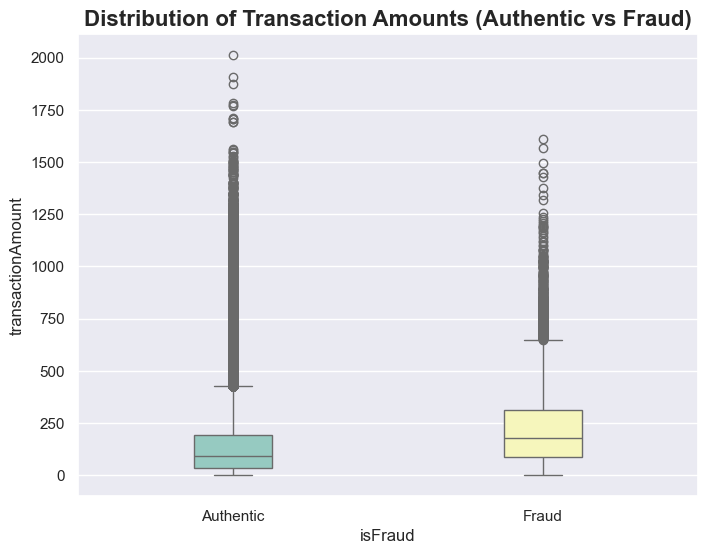

```python
plt.figure(figsize = (8, 6))
plt.title('Distribution of Transaction Amounts (Authentic vs Fraud)', weight = 'bold', fontsize = 16)
sns.set_theme()
sns.boxplot(x = 'isFraud', y = 'transactionAmount', data = clean, palette = 'Set3', width = 0.25)
plt.xticks(ticks = [0, 1], labels = ['Authentic', 'Fraud'])
```

```python
display(clean.isFraud.value_counts(), clean.isFraud.value_counts()/len(clean))
```

```
isFraud
False    709324
True      11534
Name: count, dtype: int64
```

```
isFraud
False    0.984
True     0.016
Name: count, dtype: float64
```

```python
# sampling
X = clean.copy()
y = X['isFraud']
f = X[X.isFraud == True]
X1 = X[(X.customerId.isin(f.customerId))]
X1_n = X1.sample(frac = round(len(f)/len(X1), 3), random_state = 42)
X2 = X[~(X.customerId.isin(f.customerId))]
X2_n = X2.sample(frac = round(len(f)/len(X2), 3), random_state = 42)
X.drop(['isFraud'], axis = 1, inplace = True)

rus = RandomUnderSampler(random_state = 42)
X_n, y_n = rus.fit_resample(X, y)
```

```python
# the same customers from fraud for non-fraud transactions
print("Customers from two samples are the same: {}".\
      format(f.customerId.unique().sort() == X1.customerId.unique().sort()))
# the same customers from fraud vs sampled non-fraud transactions
print("Customers from two samples are the same: {}".\
      format(f.customerId.unique().sort() == X1_n.customerId.unique().sort()))
```

```
Customers from two samples are the same: True
Customers from two samples are the same: True
```

```python
X_n['isFraud'] = y_n
Xn = pd.concat([X_n, X1_n, X2_n]).drop_duplicates()
print('Original dataset shape {}'.format(clean.shape))
print('Resampled dataset shape {}'.format(Xn.shape))
display(Xn.isFraud.value_counts())
print("Fraud percent of the sample: {:.1%}".format(len(Xn[Xn.isFraud == True])/len(Xn)))
```

```
Original dataset shape (720858, 26)
Resampled dataset shape (45266, 26)
```

```
isFraud
False    33732
True     11534
Name: count, dtype: int64
```

```
Fraud percent of the sample: 25.5%
```

```python
#Xn.to_csv('update.csv')
Xn.describe()
```

|  | accountNumber | customerId | creditLimit | availableMoney | transactionAmount | cardCVV | enteredCVV | cardLast4Digits | currentBalance |
| --- | --- | --- | --- | --- | --- | --- | --- | --- | --- |
| count | 4.526600e+04 | 4.526600e+04 | 45266.000000 | 45266.000000 | 45266.000000 | 45266.000000 | 45266.000000 | 45266.000000 | 45266.000000 |
| mean | 5.380165e+08 | 5.380165e+08 | 10689.209340 | 6616.795139 | 157.598894 | 549.430853 | 549.184686 | 4802.884748 | 4072.414201 |
| std | 2.552908e+08 | 2.552908e+08 | 11526.707213 | 9149.550565 | 162.963311 | 261.851570 | 261.845803 | 2991.039245 | 6149.647678 |
| min | 1.000881e+08 | 1.000881e+08 | 250.000000 | -658.880000 | 0.000000 | 100.000000 | 0.000000 | 0.000000 | 0.000000 |
| 25% | 3.301333e+08 | 3.301333e+08 | 5000.000000 | 1158.010000 | 41.620000 | 319.000000 | 319.000000 | 2178.000000 | 495.925000 |
| 50% | 5.094093e+08 | 5.094093e+08 | 7500.000000 | 3509.410000 | 104.550000 | 540.000000 | 539.000000 | 4816.000000 | 2099.355000 |
| 75% | 7.676200e+08 | 7.676200e+08 | 15000.000000 | 8258.165000 | 222.470000 | 793.000000 | 792.000000 | 7359.000000 | 4659.402500 |
| max | 9.992836e+08 | 9.992836e+08 | 50000.000000 | 50000.000000 | 1608.350000 | 998.000000 | 998.000000 | 9998.000000 | 47482.230000 |

```python
# standardization
def standardize(df, col):
    mu = df[col].mean()
    std = df[col].std()
    return (df[col] - mu)/std
```

```python
X['stdAmount'] = standardize(X, 'transactionAmount')
X['stdBalance'] = standardize(X, 'currentBalance')
X['stdMoney'] = standardize(X, 'availableMoney')
Xn['stdAmount'] = standardize(Xn, 'transactionAmount')
Xn['stdBalance'] = standardize(Xn, 'currentBalance')
Xn['stdMoney'] = standardize(Xn, 'availableMoney')
```

```python
newX = Xn.copy()
newy = Xn['isFraud']
newX = newX.drop(['isFraud'], axis = 1)
newX.head()
```

|  | accountNumber | customerId | creditLimit | availableMoney | transactionDateTime | transactionAmount | merchantName | acqCountry | merchantCountryCode | posEntryMode | posConditionCode | merchantCategoryCode | currentExpDate | accountOpenDate | dateOfLastAddressChange | cardCVV | enteredCVV | cardLast4Digits | transactionType | currentBalance | cardPresent | expirationDateKeyInMatch | date | matchedCVV | transactionKey | stdAmount | stdBalance | stdMoney |
| --- | --- | --- | --- | --- | --- | --- | --- | --- | --- | --- | --- | --- | --- | --- | --- | --- | --- | --- | --- | --- | --- | --- | --- | --- | --- | --- | --- | --- |
| 0 | 996709868 | 996709868 | 15000 | 14099.80 | 2016-01-07T12:45:26 | 2.76 | Delta Airlines | US | US | 2.0 | 1.0 | airline | 08/2025 | 2015-10-16 | 2015-10-16 | 234 | 234 | 8325 | PURCHASE | 900.20 | True | False | 2016-01-07 | True | T469682 | -0.950146 | -0.515837 | 0.817855 |
| 1 | 872931423 | 872931423 | 15000 | 14971.96 | 2016-11-06T13:34:48 | 5.93 | Play Store | US | US | 5.0 | 1.0 | mobileapps | 02/2028 | 2011-09-18 | 2011-09-18 | 364 | 364 | 2212 | PURCHASE | 28.04 | False | False | 2016-11-06 | True | T647954 | -0.930693 | -0.657659 | 0.913178 |
| 2 | 691172039 | 691172039 | 15000 | 14872.14 | 2016-08-10T14:46:49 | 5.36 | Play Store | US | US | 9.0 | 1.0 | mobileapps | 07/2025 | 2015-05-08 | 2015-05-08 | 920 | 920 | 315 | PURCHASE | 127.86 | False | False | 2016-08-10 | True | T331977 | -0.934191 | -0.641428 | 0.902268 |
| 3 | 413425884 | 413425884 | 15000 | 6226.33 | 2016-10-24T01:02:18 | 3.70 | Play Store | US | US | 2.0 | 1.0 | mobileapps | 12/2022 | 2015-07-18 | 2016-09-24 | 679 | 679 | 3549 | PURCHASE | 8773.67 | False | False | 2016-10-24 | True | T495716 | -0.944378 | 0.764476 | -0.042676 |
| 4 | 793511392 | 793511392 | 15000 | 2384.92 | 2016-09-18T23:50:20 | 21.14 | staples.com | US | US | 2.0 | 8.0 | online_retail | 09/2027 | 2015-05-23 | 2016-06-26 | 989 | 989 | 7957 | PURCHASE | 12615.08 | False | False | 2016-09-18 | True | T513004 | -0.837360 | 1.389131 | -0.462523 |

```python
newX = newX[['creditLimit',
            'availableMoney',
            'transactionAmount',
            'acqCountry',
            'merchantCountryCode',
            'posEntryMode',
            'posConditionCode',
            'merchantCategoryCode',
            'transactionType',
            'currentBalance',
            'cardPresent',
            'expirationDateKeyInMatch',
            'matchedCVV', 'stdAmount', 'stdBalance', 'stdMoney']]
```

```python
Xx = X[['creditLimit',
        'availableMoney',
        'transactionAmount',
        'acqCountry',
        'merchantCountryCode',
        'posEntryMode',
        'posConditionCode',
        'merchantCategoryCode',
        'transactionType',
        'currentBalance',
        'cardPresent',
        'expirationDateKeyInMatch',
        'matchedCVV', 'stdAmount', 'stdBalance', 'stdMoney']]
```

```python
x_train, x_test, y_train, y_test = train_test_split(newX, newy)

pipeline = ColumnTransformer([('cat_pipe',
                               Pipeline([('cat_imputer', SimpleImputer(strategy = 'most_frequent')),
                                         ('one_hot', OneHotEncoder(handle_unknown = 'ignore'))]),
                               ['merchantCountryCode',
                                'merchantCategoryCode',
                                'posConditionCode',
                                'posEntryMode',
                                'transactionType',
                                'acqCountry'])
                             ], remainder = 'passthrough')

remaining_columns = [x for x in Xx.columns if x not in ['merchantCountryCode',
                                                        'merchantCategoryCode',
                                                        'posConditionCode',
                                                        'posEntryMode',
                                                        'transactionType',
                                                        'acqCountry']]

x_train = pipeline.fit_transform(x_train)
x_test = pipeline.transform(x_test)

clustered_preproc_data = pipeline.fit_transform(Xx) #.todense()

remaining_columns = list(pipeline.named_transformers_['cat_pipe']['one_hot'].get_feature_names_out()) + remaining_columns

upd_data = pd.DataFrame(clustered_preproc_data, columns = remaining_columns)
upd_data['isFraud'] = y
upd_data['accountNumber'] = X.accountNumber
upd_data.to_csv('upd_data.csv')

sample_data = {'x_train': x_train, 'x_test': x_test, 'y_train': y_train, 'y_test': y_test}
```

```python
print("Dimension of transformed dataset: {}".format(x_train.shape))
```

```
Dimension of transformed dataset: (33949, 46)
```

##### Dimensions grew larger due to one hot encoding, but it is not a significant increase since most features did not have many unique values

```python
# Random Forest with Randomized Search
from sklearn.ensemble import RandomForestClassifier
from sklearn.model_selection import RandomizedSearchCV
model_params = {'n_estimators': range(650, 750, 50),
                'max_depth': range(10, 14),
                'min_samples_split': range(5, 10)}

# create random forest classifier model
rf_model = RandomForestClassifier()

# set up random search meta-estimator
clf = RandomizedSearchCV(rf_model, model_params, n_iter = 50, cv = 4, scoring = 'f1',random_state = 42)

# train the random search meta-estimator to find the best model out of 100 candidates
model = clf.fit(x_train, y_train)

model.best_estimator_
```

```python
# run with opt hyperparams
rf = RandomForestClassifier(bootstrap = True, ccp_alpha = 0.0, class_weight = None,
                            criterion = 'gini', max_depth = 13,
                            max_leaf_nodes = None, max_samples = None,
                            min_impurity_decrease = 0.0,
                            min_samples_leaf = 1, min_samples_split = 5,
                            min_weight_fraction_leaf = 0.0, n_estimators = 700,
                            n_jobs = None, oob_score = False, random_state = None,
                            verbose = 0, warm_start = False)

# train the model using the training sets
rf.fit(x_train, y_train)

y_pred = rf.predict(x_test)
```

```
(array([0.5, 1.5]),
 [Text(0, 0.5, 'Actual Positive: 0'), Text(0, 1.5, 'Actual Negative: 1')])
```

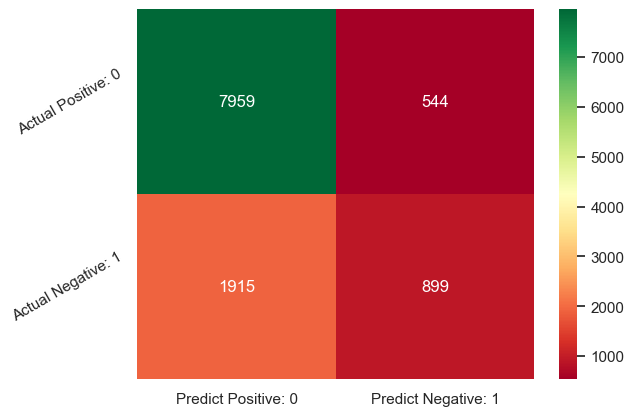

```python
# visualize confusion matrix with seaborn heatmap
CM = confusion_matrix(y_test, y_pred)

cm_matrix = pd.DataFrame(data = CM, columns = ['Predict Positive: 0', 'Predict Negative: 1'],
                         index = ['Actual Positive: 0', 'Actual Negative: 1'])
sns.heatmap(cm_matrix, annot = True, fmt = 'd', cmap = 'RdYlGn')
plt.yticks(rotation = 30)
```

```python
# Model Accuracy, how often is the classifier correct?
print("Accuracy:", round(accuracy_score(y_test, y_pred), 3))
# Precision score on the test data
print("Precision Score:", round(precision_score(y_test, y_pred), 3))
# F1 score on the test data
print("F1 Score:", round(f1_score(y_test, y_pred), 3))
```

```
Accuracy: 0.783
Precision Score: 0.623
F1 Score: 0.422
```

```python
def plot_feature_importance(importance, names, model_type):

    #Create arrays from feature importance and feature names
    feature_importance = np.array(importance)
    feature_names = np.array(names)

    #Create a DataFrame using a Dictionary
    data={'feature_names': feature_names, 'feature_importance': feature_importance}
    fi_df = pd.DataFrame(data)

    #Sort the DataFrame in order decreasing feature importance
    fi_df.sort_values(by = ['feature_importance'], ascending = False, inplace = True)

    #Define size of bar plot
    plt.figure(figsize = (18, 12))
    #Plot Searborn bar chart
    sns.barplot(x = fi_df['feature_importance'], y = fi_df['feature_names'], palette = 'Set2')
    #Add chart labels
    plt.title(model_type + " " + 'Feature Importance' , weight = 'bold')
    plt.xlabel('Feature Importance')
    plt.ylabel('Feature Names')
```

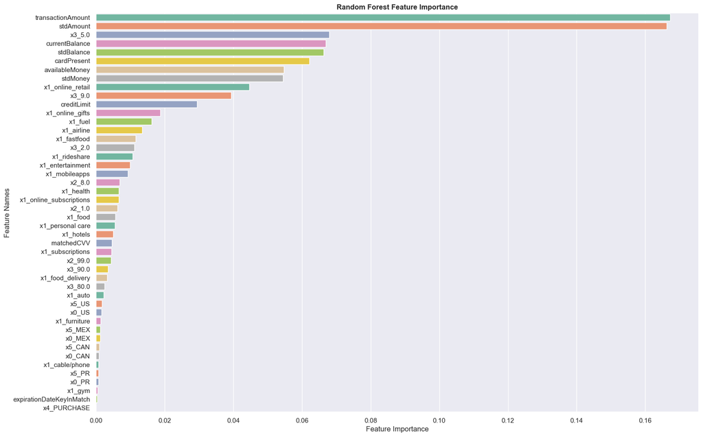

```python
plot_feature_importance(rf.feature_importances_, remaining_columns, 'Random Forest')
```

```python
# define Gradient Boosting model
gbm = GradientBoostingClassifier(n_estimators = 800,
                                 learning_rate = 0.01,
                                 max_depth = 6,
                                 random_state = 42).fit(x_train, y_train)
# take predictions on the test data
ypred = gbm.predict(x_test)
```

```
(array([0.5, 1.5]),
 [Text(0, 0.5, 'Actual Positive: 0'), Text(0, 1.5, 'Actual Negative: 1')])
```

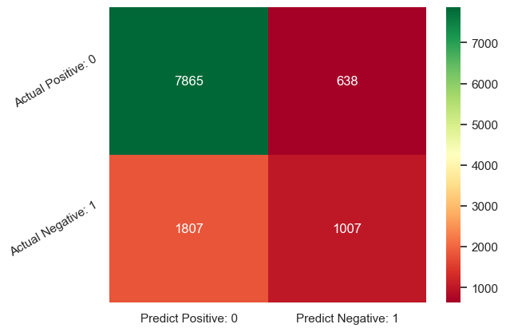

```python
# visualize confusion matrix with seaborn heatmap
gb = confusion_matrix(y_test, ypred)

gb_matrix = pd.DataFrame(data = gb, columns = ['Predict Positive: 0', 'Predict Negative: 1'],
                         index = ['Actual Positive: 0', 'Actual Negative: 1'])
sns.heatmap(gb_matrix, annot = True, fmt = 'd', cmap = 'RdYlGn')
plt.yticks(rotation = 30)
```

```python
# Model Accuracy, how often is the classifier correct?
print("Accuracy:", round(accuracy_score(y_test, ypred), 3))
# Precision score on the test data
print("Precision Score:", round(precision_score(y_test, ypred), 3))
# F1 score on the test data
print("F1 Score:", round(f1_score(y_test, ypred), 3))
```

```
Accuracy: 0.784
Precision Score: 0.612
F1 Score: 0.452
```

```python
import xgboost as xgb
from xgboost import XGBClassifier
from sklearn.model_selection import GridSearchCV

xgb = xgb.XGBClassifier(objective= 'binary:logistic', nthread = 4, seed = 123)

params = {'max_depth': range(5, 10, 2), 'n_estimators': range(900, 1000, 50), 'learning_rate': [0.01, 0.005]}

grid_search = GridSearchCV(estimator = xgb,
                           param_grid = params,
                           scoring = 'f1',
                           n_jobs = 10,
                           cv = 4,
                           verbose=True)

grid_search.fit(x_train, y_train)
grid_search.best_estimator_
```

```python
import xgboost as xgb
from xgboost import XGBClassifier
from sklearn.model_selection import GridSearchCV

xgbm = xgb.XGBClassifier(base_score=0.5, booster='gbtree', colsample_bylevel=1,
          colsample_bynode=1, colsample_bytree=1, gamma=0, gpu_id=-1,
          importance_type='gain', interaction_constraints='',
          learning_rate=0.01, max_delta_step=0, max_depth=9,
          min_child_weight=1, missing=1, monotone_constraints='()',
          n_estimators=950, n_jobs=8, num_parallel_tree=1, random_state=45,
          reg_alpha=0, reg_lambda=1, scale_pos_weight=1, subsample=1,
          tree_method='exact', validate_parameters=1, verbosity=None)

#Fit the model
xgbm.fit(x_train,y_train)

#Predict the model
predy = xgbm.predict(x_test)
```

```
(array([0.5, 1.5]),
 [Text(0, 0.5, 'Actual Positive: 0'), Text(0, 1.5, 'Actual Negative: 1')])
```

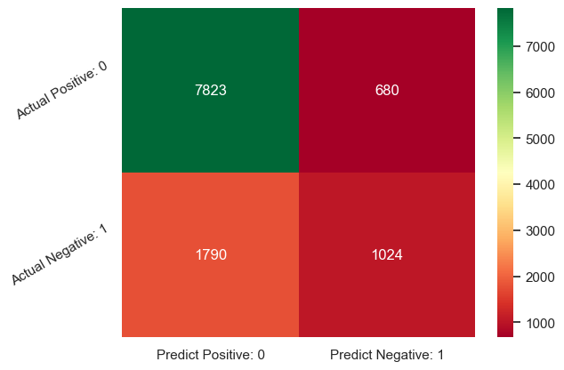

```python
# visualize confusion matrix with seaborn heatmap
CM_xgb = confusion_matrix(y_test, predy)

mxgbm = pd.DataFrame(data = CM_xgb, columns = ['Predict Positive: 0', 'Predict Negative: 1'],
                     index = ['Actual Positive: 0', 'Actual Negative: 1'])
sns.heatmap(mxgbm, annot = True, fmt = 'd', cmap = 'RdYlGn')
plt.yticks(rotation = 30)
```

```python
# Model Accuracy, how often is the classifier correct?
print("Accuracy:", round(accuracy_score(y_test, predy), 3))
# Precision score on the test data
print("Precision Score:", round(precision_score(y_test, predy), 3))
# F1 score on the test data
print("F1 Score:", round(f1_score(y_test, predy), 3))
```

```
Accuracy: 0.782
Precision Score: 0.601
F1 Score: 0.453
```

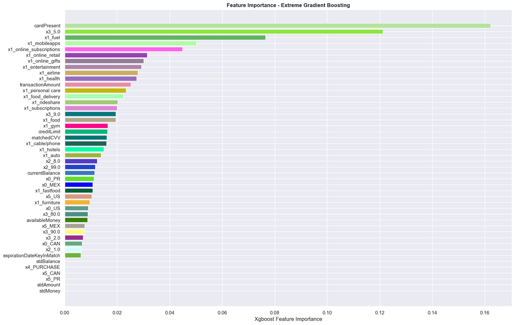

```python
plt.figure(figsize = (18, 12))
plt.title('Feature Importance - Extreme Gradient Boosting', weight = 'bold')
sns.set_theme()
sorted_idx = xgbm.feature_importances_.argsort()
col_names = []
for i in sorted_idx:
    col_names.append(remaining_columns[i])
plt.barh(col_names, xgbm.feature_importances_[sorted_idx], color = mcolors.XKCD_COLORS)
plt.xlabel("Xgboost Feature Importance")
```

```python
def plot_roc(models):
    for key, value in models.items():
        fpr, tpr, _ = roc_curve(value[0], value[1])
        sns.lineplot(x=fpr, y=tpr, label=key)

    ax = sns.lineplot(x=[0, 0.5, 1], y=[0, 0.5, 1])
    ax.lines[len(models)].set_linestyle("--")
    plt.xlabel('False Positive Rate')
    plt.ylabel('True Positive Rate')
    plt.title(f'ROC Curve')
```

```python
rF = [y_test.array, y_pred]
gBM = [y_test.array, ypred]
xGB = [y_test.array, predy]
```

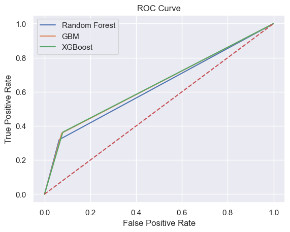

```python
model_results = {
    'Random Forest': rF,
    'GBM': gBM,
    'XGBoost': xGB
}
plot_roc(model_results)
```